# Gutenberg Corpus

A clean start to get my corpus up and running.

```r
# This is to group all libraries for import (a style found in most programming languages)
library(gutenbergr)
library(dplyr)
library(tidytext)
library(tidyr)
library(stringr)
library(scales)
library(ggplot2)
```

```r
# this filters out from gutenberg_metadata ( )
gutenberg_metadata %>% filter(author == "Carroll, Lewis", str_detect(gutenberg_bookshelf, "Children's Literature"), language == "en",  has_text, !str_detect(title, "facsimile")) %>% distinct(title)
```

| title |
| --- |
| Alice's Adventures in Wonderland |
| Through the Looking-Glass |
| The Hunting of the Snark: An Agony in Eight Fits |

Note to self: gutenberg_download(meta_fields = “title”, “author”) will not run. gutenberg_download(meta_fields = c(“title”, “author”)) will run.

```r
carroll <- gutenberg_works(author == "Carroll, Lewis", str_detect(gutenberg_bookshelf, "Children's Literature"), !str_detect(title, "facsimile")) %>%
  gutenberg_download(meta_fields = c("title", "author"))
```

```
Determining mirror for Project Gutenberg from http://www.gutenberg.org/robot/harvest
Using mirror http://aleph.gutenberg.org
```

```r
gutenberg_metadata %>% filter(author == "Baum, L. Frank (Lyman Frank)", str_detect(gutenberg_bookshelf, "Children's Literature"), language == "en",  has_text) %>% distinct(title)
```

| title |
| --- |
| The Marvelous Land of Oz |
| The Wonderful Wizard of Oz |
| The Magic of Oz |
| Dorothy and the Wizard in Oz |
| The Master Key: An Electrical Fairy Tale Founded Upon the Mysteries of Electricity |
| The Road to Oz |
| Ozma of Oz |
| The Emerald City of Oz |
| The Enchanted Island of Yew\r\nWhereon Prince Marvel Encountered the High Ki of Twi and Other Surprising People |
| A Kidnapped Santa Claus |

[output cut: 17 more lines]

```r
frank <- gutenberg_works(author == "Baum, L. Frank (Lyman Frank)", str_detect(gutenberg_bookshelf, "Children's Literature")) %>%
  gutenberg_download(meta_fields = c("title", "author"))
```

```
Could not download a book at http://aleph.gutenberg.org/1/9/4/6/19467/19467.zip
```

Could not download Little Wizard Stories of Oz (which is ok)

```r
gutenberg_metadata %>% filter(author == "Milne, A. A. (Alan Alexander)", str_detect(gutenberg_bookshelf, "Detective Fiction"), language == "en",  has_text) %>% distinct(title)
```

| title |
| --- |
| The Red House Mystery |

```r
alanalexander <- gutenberg_works(author == "Milne, A. A. (Alan Alexander)", str_detect(gutenberg_bookshelf, "Detective Fiction")) %>%
  gutenberg_download(meta_fields = c("title", "author"))
```

This only has one work: The Red House Mystery. I felt it as a nice addition to still include AA Milne even though Winnie The Pooh remains unavailable on gutenberg

```r
gutenberg_metadata %>% filter(author == "Doyle, Arthur Conan", str_detect(gutenberg_bookshelf, "Detective Fiction"), language == "en",  has_text) %>% distinct(title)
```

| title |
| --- |
| The Return of Sherlock Holmes |
| A Study in Scarlet |
| The Memoirs of Sherlock Holmes |
| The Adventures of Sherlock Holmes |
| The Sign of the Four |
| The Adventure of Wisteria Lodge |
| The Adventure of the Cardboard Box |
| The Adventure of the Red Circle |
| The Adventure of the Bruce-Partington Plans |
| The Adventure of the Dying Detective |

[output cut: 5 more lines]

```r
arthur <- gutenberg_works(author == "Doyle, Arthur Conan", str_detect(gutenberg_bookshelf, "Detective Fiction")) %>%
  gutenberg_download(meta_fields = c("title", "author"))
```

Finally, 4 corpora that have only detective fiction and children’s literature Now to simplify them into 2 corpus (one of Children’s Literature and the other of Detective Fiction)

```r
childrensLit <- bind_rows(carroll, frank)
detectiveFiction <- bind_rows(arthur, alanalexander)
```

```r
# to check and see if page numbers and chapter numbers would interfere with the word frequency count for childrens lit corpus (they will)
test <- childrensLit %>% filter(str_detect(text, regex("[0-9]"))) %>% select(text)
```

```r
# Adds the number of words in each str vector
test$charcount = str_count(test$text, "\\S+")
```

```r
# all of the numbers (without chapter titles?)
# i found that the most amount of words for in text numbers is around 10 or more words
dat1 <- filter(test, charcount < 10 && !str_detect(text, regex("chapter", ignore_case = )))
```

```r
# lets take out the numbers
childsLit_clean <- childrensLit[!childrensLit$text %in% dat1$text, , drop = FALSE]
```

```r
# seeing chapter names in the cleaned corpus
filter(childsLit_clean, str_detect(text, regex("^chapter ", ignore_case = TRUE)))
```

| gutenberg_id | text | title | author |
| --- | --- | --- | --- |
| 11 | CHAPTER I. Down the Rabbit-Hole | Alice's Adventures in Wonderland | Carroll, Lewis |
| 11 | CHAPTER II. The Pool of Tears | Alice's Adventures in Wonderland | Carroll, Lewis |
| 11 | CHAPTER III. A Caucus-Race and a Long Tale | Alice's Adventures in Wonderland | Carroll, Lewis |
| 11 | CHAPTER IV. The Rabbit Sends in a Little Bill | Alice's Adventures in Wonderland | Carroll, Lewis |
| 11 | CHAPTER V. Advice from a Caterpillar | Alice's Adventures in Wonderland | Carroll, Lewis |
| 11 | CHAPTER VI. Pig and Pepper | Alice's Adventures in Wonderland | Carroll, Lewis |
| 11 | CHAPTER VII. A Mad Tea-Party | Alice's Adventures in Wonderland | Carroll, Lewis |
| 11 | CHAPTER VIII. The Queen's Croquet-Ground | Alice's Adventures in Wonderland | Carroll, Lewis |
| 11 | CHAPTER IX. The Mock Turtle's Story | Alice's Adventures in Wonderland | Carroll, Lewis |
| 11 | CHAPTER X. The Lobster Quadrille | Alice's Adventures in Wonderland | Carroll, Lewis |

[output cut: 193 more lines]

```r
# to check and see if page numbers and chapter numbers would interfere with the word frequency count for detective fiction corpus (they will not)
detectiveFiction %>% filter(str_detect(text, regex("[0-9]"))) %>% select(text)
```

| text |
| --- |
| It was in the spring of the year 1894 that all London was interested, |
| 427 Park Lane. The youth moved in the best society--had, so far as was |
| the hours of ten and eleven-twenty on the night of March 30, 1894. |
| My observations of No. 427 Park Lane did little to clear up the problem |
| front of No. 427 Park Lane, upon the thirtieth of last month. That's the |
| MORAN, SEBASTIAN, COLONEL. Unemployed. Formerly 1st Bangalore Pioneers. |
| Born London, 1840. Son of Sir Augustus Moran, C. B., once British |
| HEAVY GAME OF THE WESTERN HIMALAYAS (1881); THREE MONTHS IN THE |
| JUNGLE (1884). Address: Conduit Street. Clubs: The Anglo-Indian, the |
| some recollection of the death of Mrs. Stewart, of Lauder, in 1887. |

[output cut: 423 more lines]

```r
# This is to set chapter numbers next to the text
child_books <- childrensLit %>%
  group_by(title) %>%
  mutate(linenumber = row_number(),
         chapter = cumsum(str_detect(text, regex("^chapter [\\divxlc]", ignore_case = TRUE)))) %>%   ungroup()
```

```r
detective_books <- detectiveFiction %>%
  group_by(title) %>%
  mutate(linenumber = row_number(),
         chapter = cumsum(str_detect(text, regex("^chapter [\\divxlc]", ignore_case = TRUE)))) %>%   ungroup()
```

Some texts do not have a mention of chapters and should be adjusted accordingly

# Week 3

```r
# upload all words in detective corpus except for the stop_words
tidy_detective <- detective_books %>%
  unnest_tokens(word, text) %>%
  anti_join(stop_words)
```

```r
# sort remaining words by the most frequent
tidy_detective %>%
  count(word, sort = TRUE)
```

| word | n |
| --- | --- |
| holmes | 2408 |
| time | 1003 |
| house | 930 |
| sir | 907 |
| door | 831 |
| watson | 830 |
| night | 758 |
| hand | 694 |
| found | 619 |
| left | 594 |

[output cut: 990 more lines]

```r
# upload all words in childrens lit corpus except for the stop_words
tidy_childrensLit <- child_books %>%
  unnest_tokens(word, text) %>%
  anti_join(stop_words)
```

```r
# sort remaining words by the most frequent
tidy_childrensLit %>%
  count(word, sort = TRUE)
```

| word | n |
| --- | --- |
| dorothy | 2579 |
| king | 2452 |
| time | 2032 |
| girl | 1729 |
| people | 1612 |
| oz | 1589 |
| head | 1479 |
| replied | 1409 |
| boy | 1379 |
| trot | 1354 |

[output cut: 990 more lines]

```r
# calculates frequency and combines detective and childrens copus into one variable
frequency_dc <- bind_rows(mutate(tidy_detective, corpus = "Detective"), mutate(tidy_childrensLit, corpus = "Children's Literature")) %>%
  mutate(word = str_extract(word, "[a-z']+")) %>%
  count(corpus, word) %>%
  group_by(corpus) %>%
  mutate(proportion = n / sum(n)) %>%
  select(-n) %>%
  spread(corpus, proportion) %>%
  gather(corpus, proportion, `Detective`)
```

This Data Wrangling Cheat Sheet helped me so much in understanding what the functions were doing as well as what I needed to alter to adjust the functions to fit my needs

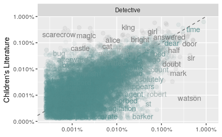

```r
ggplot(frequency_dc, aes(x = proportion, y = `Children's Literature`, color = abs(`Children's Literature` - proportion))) +
  geom_abline(color = "gray40", lty = 2) +
  geom_jitter(alpha = 0.1, size = 2.5, width = 0.3, height = 0.3) +
  geom_text(aes(label = word), check_overlap = TRUE, vjust = 1.5) +
  scale_x_log10(labels = percent_format()) +
  scale_y_log10(labels = percent_format()) +
  scale_color_gradient(limits = c(0, 0.001), low = "darkslategray4", high = "gray75") +
  facet_wrap(~corpus, ncol = 2) +
  theme(legend.position="none") +
  labs(y = "Children's Literature", x = NULL)
```

```r
cor.test(data = frequency_dc[frequency_dc$corpus == "Detective",],
         ~ proportion + `Children's Literature`)
```

```
    Pearson's product-moment correlation

data:  proportion and Children's Literature
t = 72.247, df = 10553, p-value < 2.2e-16
alternative hypothesis: true correlation is not equal to 0
95 percent confidence interval:
 0.5623607 0.5878925
sample estimates:
      cor
0.5752667
```

## Week 3 More

```r
clbook_words <- childsLit_clean %>%
  unnest_tokens(word, text) %>%
  count(title, word, sort = TRUE) %>%
  ungroup()
cltotal_words <- clbook_words %>%
  group_by(title) %>%
  summarize(total = sum(n))
clbook_words <- left_join(clbook_words, cltotal_words)
```

```r
dbook_words <- detective_books %>%
  unnest_tokens(word, text) %>%
  count(title, word, sort = TRUE) %>%
  ungroup()
dtotal_words <- dbook_words %>%
  group_by(title) %>%
  summarize(total = sum(n))
dbook_words <- left_join(dbook_words, dtotal_words)
```

[figure not shown]

```r
ggplot(clbook_words, aes(n/total, fill = title)) +
  geom_histogram(show.legend = FALSE) +
  xlim(NA, 0.0009) +
  facet_wrap(~title, ncol = 6, scales = "free_y")
```

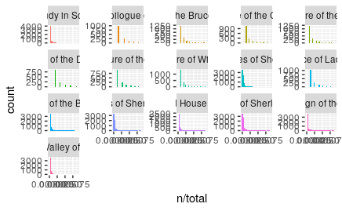

```r
ggplot(dbook_words, aes(n/total, fill = title)) +
  geom_histogram(show.legend = FALSE) +
  xlim(NA, 0.0009) +
  facet_wrap(~title, ncol = 5, scales = "free_y")
```

```r
clfreq_by_rank <- clbook_words %>%
  group_by(title) %>%
  mutate(rank = row_number(),
         `term frequency` = n/total)
clfreq_by_rank
```

| title | word | n | total | rank | term frequency |
| --- | --- | --- | --- | --- | --- |
| Sky Island: being the further exciting adventures of Trot and Cap'n Bill after their visit to the sea fairies | the | 3995 | 55148 | 1 | 0.072441430 |
| The Patchwork Girl of Oz | the | 3835 | 57646 | 1 | 0.066526732 |
| The Emerald City of Oz | the | 3368 | 53617 | 1 | 0.062815898 |
| Rinkitink in Oz | the | 3362 | 49482 | 1 | 0.067943899 |
| The Lost Princess of Oz | the | 3267 | 47593 | 1 | 0.068644549 |
| The Marvelous Land of Oz | the | 3263 | 42295 | 1 | 0.077148599 |
| Mother Goose in Prose | the | 3159 | 46070 | 1 | 0.068569568 |
| Dorothy and the Wizard in Oz | the | 3121 | 42053 | 1 | 0.074215870 |
| The Scarecrow of Oz | the | 3034 | 46048 | 1 | 0.065887769 |
| The Magic of Oz | the | 2957 | 39386 | 1 | 0.075077439 |

[output cut: 990 more lines]

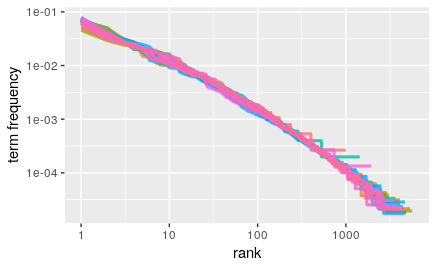

```r
clfreq_by_rank %>%
  ggplot(aes(rank, `term frequency`, color = title)) +
  geom_line(size = 1.1, alpha = 0.8, show.legend = FALSE) +
  scale_x_log10() +
  scale_y_log10()
```

```r
rank_subset <- freq_by_rank %>%
  filter(rank < 100,
         rank > 10)
lm(log10(`term frequency`) ~ log10(rank), data = rank_subset)
```

```
Call:
lm(formula = log10(`term frequency`) ~ log10(rank), data = rank_subset)

Coefficients:
(Intercept)  log10(rank)
    -0.7667      -1.0239
```

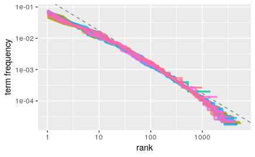

```r
clfreq_by_rank %>%
  ggplot(aes(rank, `term frequency`, color = title)) +
  geom_abline(intercept = -0.76, slope = -1, color = "gray50", linetype = 2) +
  geom_line(size = 1.1, alpha = 0.8, show.legend = FALSE) +
  scale_x_log10() +
  scale_y_log10()
```

```r
dfreq_by_rank <- dbook_words %>%
  group_by(title) %>%
  mutate(rank = row_number(),
         `term frequency` = n/total)
dfreq_by_rank
```

| title | word | n | total | rank | term frequency |
| --- | --- | --- | --- | --- | --- |
| The Return of Sherlock Holmes | the | 6266 | 113201 | 1 | 0.0553528679 |
| The Adventures of Sherlock Holmes | the | 5630 | 105426 | 1 | 0.0534023865 |
| The Memoirs of Sherlock Holmes | the | 4988 | 88373 | 1 | 0.0564425786 |
| The Hound of the Baskervilles | the | 3331 | 59517 | 1 | 0.0559672026 |
| The Valley of Fear | the | 3266 | 57993 | 1 | 0.0563171417 |
| The Adventures of Sherlock Holmes | and | 3018 | 105426 | 2 | 0.0286267145 |
| The Adventures of Sherlock Holmes | i | 3003 | 105426 | 3 | 0.0284844346 |
| The Red House Mystery | the | 2975 | 61119 | 1 | 0.0486755346 |
| The Return of Sherlock Holmes | i | 2922 | 113201 | 2 | 0.0258124928 |
| The Return of Sherlock Holmes | and | 2919 | 113201 | 3 | 0.0257859913 |

[output cut: 990 more lines]

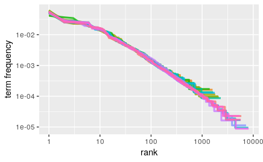

```r
dfreq_by_rank %>%
  ggplot(aes(rank, `term frequency`, color = title)) +
  geom_line(size = 1.1, alpha = 0.8, show.legend = FALSE) +
  scale_x_log10() +
  scale_y_log10()
```

```r
rank_subset <- dfreq_by_rank %>%
  filter(rank < 500,
         rank > 65)
lm(log10(`term frequency`) ~ log10(rank), data = rank_subset)
```

```
Call:
lm(formula = log10(`term frequency`) ~ log10(rank), data = rank_subset)

Coefficients:
(Intercept)  log10(rank)
     -0.658       -1.095
```

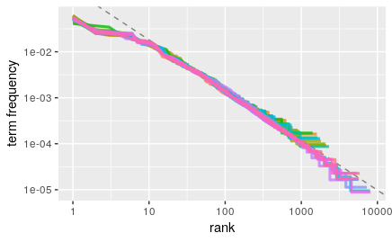

```r
dfreq_by_rank %>%
  ggplot(aes(rank, `term frequency`, color = title)) +
  geom_abline(intercept = -0.65, slope = -1.09, color = "gray50", linetype = 2) +
  geom_line(size = 1.1, alpha = 0.8, show.legend = FALSE) +
  scale_x_log10() +
  scale_y_log10()
```

```r
clbook_words <- clbook_words %>%
  bind_tf_idf(word, title, n)
clbook_words
```

| title | word | n | total | tf | idf | tf_idf |
| --- | --- | --- | --- | --- | --- | --- |
| Sky Island: being the further exciting adventures of Trot and Cap'n Bill after their visit to the sea fairies | the | 3995 | 55148 | 0.072441430 | 0.00000000 | 0.0000000000 |
| The Patchwork Girl of Oz | the | 3835 | 57646 | 0.066526732 | 0.00000000 | 0.0000000000 |
| The Emerald City of Oz | the | 3368 | 53617 | 0.062815898 | 0.00000000 | 0.0000000000 |
| Rinkitink in Oz | the | 3362 | 49482 | 0.067943899 | 0.00000000 | 0.0000000000 |
| The Lost Princess of Oz | the | 3267 | 47593 | 0.068644549 | 0.00000000 | 0.0000000000 |
| The Marvelous Land of Oz | the | 3263 | 42295 | 0.077148599 | 0.00000000 | 0.0000000000 |
| Mother Goose in Prose | the | 3159 | 46070 | 0.068569568 | 0.00000000 | 0.0000000000 |
| Dorothy and the Wizard in Oz | the | 3121 | 42053 | 0.074215870 | 0.00000000 | 0.0000000000 |
| The Scarecrow of Oz | the | 3034 | 46048 | 0.065887769 | 0.00000000 | 0.0000000000 |
| The Magic of Oz | the | 2957 | 39386 | 0.075077439 | 0.00000000 | 0.0000000000 |

[output cut: 990 more lines]

```r
dbook_words <- dbook_words %>%
  bind_tf_idf(word, title, n)
dbook_words
```

| title | word | n | total | tf | idf | tf_idf |
| --- | --- | --- | --- | --- | --- | --- |
| The Return of Sherlock Holmes | the | 6266 | 113201 | 0.0553528679 | 0.00000000 | 0.000000e+00 |
| The Adventures of Sherlock Holmes | the | 5630 | 105426 | 0.0534023865 | 0.00000000 | 0.000000e+00 |
| The Memoirs of Sherlock Holmes | the | 4988 | 88373 | 0.0564425786 | 0.00000000 | 0.000000e+00 |
| The Hound of the Baskervilles | the | 3331 | 59517 | 0.0559672026 | 0.00000000 | 0.000000e+00 |
| The Valley of Fear | the | 3266 | 57993 | 0.0563171417 | 0.00000000 | 0.000000e+00 |
| The Adventures of Sherlock Holmes | and | 3018 | 105426 | 0.0286267145 | 0.00000000 | 0.000000e+00 |
| The Adventures of Sherlock Holmes | i | 3003 | 105426 | 0.0284844346 | 0.00000000 | 0.000000e+00 |
| The Red House Mystery | the | 2975 | 61119 | 0.0486755346 | 0.00000000 | 0.000000e+00 |
| The Return of Sherlock Holmes | i | 2922 | 113201 | 0.0258124928 | 0.00000000 | 0.000000e+00 |
| The Return of Sherlock Holmes | and | 2919 | 113201 | 0.0257859913 | 0.00000000 | 0.000000e+00 |

[output cut: 990 more lines]

```r
clbook_words %>%
  select(-total) %>%
  arrange(desc(tf_idf))
```

| title | word | n | tf | idf | tf_idf |
| --- | --- | --- | --- | --- | --- |
| Through the Looking-Glass | alice | 434 | 0.0146191936 | 2.67414865 | 0.0390938968 |
| Alice's Adventures in Wonderland | alice | 386 | 0.0144628873 | 2.67414865 | 0.0386759106 |
| A Kidnapped Santa Claus | daemon | 27 | 0.0071675073 | 3.36729583 | 0.0241351174 |
| The Enchanted Island of Yew\r\nWhereon Prince Marvel Encountered the High Ki of Twi and Other Surprising People | ki | 331 | 0.0088942631 | 2.67414865 | 0.0237845816 |
| The Hunting of the Snark: An Agony in Eight Fits | snark | 33 | 0.0065463202 | 3.36729583 | 0.0220433966 |
| The Woggle-Bug Book | woggle | 104 | 0.0139074619 | 1.57553636 | 0.0219117119 |
| The Hunting of the Snark: An Agony in Eight Fits | bellman | 32 | 0.0063479468 | 3.36729583 | 0.0213754149 |
| A Kidnapped Santa Claus | santa | 53 | 0.0140695514 | 1.42138568 | 0.0199982589 |
| Rinkitink in Oz | inga | 286 | 0.0057798796 | 3.36729583 | 0.0194625643 |
| The Tin Woodman of Oz\r\nA Faithful Story of the Astonishing Adventure Undertaken by the Tin Woodman, Assisted by Woot the Wanderer, the Scarecrow of Oz, and Polychrome, the Rainbow's Daughter | woot | 248 | 0.0055754142 | 3.36729583 | 0.0187740691 |

[output cut: 990 more lines]

```r
dbook_words %>%
  select(-total) %>%
  arrange(desc(tf_idf))
```

| title | word | n | tf | idf | tf_idf |
| --- | --- | --- | --- | --- | --- |
| The Red House Mystery | antony | 457 | 0.0074772166 | 2.7725887 | 0.0207312464 |
| The Red House Mystery | cayley | 402 | 0.0065773327 | 2.7725887 | 0.0182362386 |
| His Last Bow: An Epilogue of Sherlock Holmes | bork | 34 | 0.0055221699 | 2.7725887 | 0.0153107060 |
| The Adventure of the Devil's Foot | tregennis | 36 | 0.0035767511 | 2.7725887 | 0.0099168598 |
| The Disappearance of Lady Frances Carfax | frances | 26 | 0.0033544059 | 2.7725887 | 0.0093003879 |
| The Adventure of the Cardboard Box | cushing | 27 | 0.0031052329 | 2.7725887 | 0.0086095337 |
| The Adventure of the Red Circle | gennaro | 22 | 0.0029838600 | 2.7725887 | 0.0082730167 |
| The Adventure of Wisteria Lodge | baynes | 32 | 0.0027835769 | 2.7725887 | 0.0077177139 |
| The Red House Mystery | bill | 457 | 0.0074772166 | 0.9808293 | 0.0073338728 |
| His Last Bow: An Epilogue of Sherlock Holmes | von | 38 | 0.0061718369 | 1.1631508 | 0.0071787771 |

[output cut: 990 more lines]

[figure not shown]

```r
clbook_words %>%
  arrange(desc(tf_idf)) %>%
  mutate(word = factor(word, levels = rev(unique(word)))) %>%
  group_by(title) %>%
  top_n(15) %>%
  ungroup %>%
  ggplot(aes(word, tf_idf, fill = title)) +
  geom_col(show.legend = FALSE) +
  labs(x = NULL, y = "tf-idf") +
  facet_wrap(~title, ncol = 6, scales = "free") +
  coord_flip()
```

[figure not shown]

```r
dbook_words %>%
  arrange(desc(tf_idf)) %>%
  mutate(word = factor(word, levels = rev(unique(word)))) %>%
  group_by(title) %>%
  top_n(15) %>%
  ungroup %>%
  ggplot(aes(word, tf_idf, fill = title)) +
  geom_col(show.legend = FALSE) +
  labs(x = NULL, y = "tf-idf") +
  facet_wrap(~title, ncol = 5, scales = "free") +
  coord_flip()
```

```r
corpus_all <- bind_rows(child_books, detective_books)
```

```r
allcorpus_words <- corpus_all %>%
  unnest_tokens(word, text) %>%
  count(author, word, sort = TRUE) %>%
  ungroup()
```

```r
allcorpus_words
```

| author | word | n |
| --- | --- | --- |
| Baum, L. Frank (Lyman Frank) | the | 71190 |
| Baum, L. Frank (Lyman Frank) | and | 39431 |
| Doyle, Arthur Conan | the | 32029 |
| Baum, L. Frank (Lyman Frank) | to | 29897 |
| Baum, L. Frank (Lyman Frank) | of | 23496 |
| Baum, L. Frank (Lyman Frank) | a | 21760 |
| Doyle, Arthur Conan | and | 15659 |
| Doyle, Arthur Conan | of | 14809 |
| Doyle, Arthur Conan | i | 14432 |
| Baum, L. Frank (Lyman Frank) | in | 14405 |

[output cut: 990 more lines]

```r
plot_all <- allcorpus_words %>%
  bind_tf_idf(word, author, n) %>%
  arrange(desc(tf_idf)) %>%
  mutate(word = factor(word, levels = rev(unique(word)))) %>%
  mutate(author = factor(author, levels = c("Baum, L. Frank (Lyman Frank)",
                                            "Doyle, Arthur Conan",
                                            "Carroll, Lewis",
                                            "Milne, A. A. (Alan Alexander)")))
```

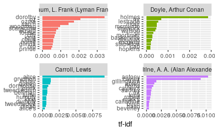

```r
plot_all %>%
  group_by(author) %>%
  top_n(15, tf_idf) %>%
  ungroup() %>%
  mutate(word = reorder(word, tf_idf)) %>%
  ggplot(aes(word, tf_idf, fill = author)) +
  geom_col(show.legend = FALSE) +
  labs(x = NULL, y = "tf-idf") +
  facet_wrap(~author, ncol = 2, scales = "free") +
  coord_flip()
```

This is my revision attempt at Week 3.